# TempDisc

Kendra Seaman

5/19/2020

# Domain (Money x Health x Social) ANCOVA with Age

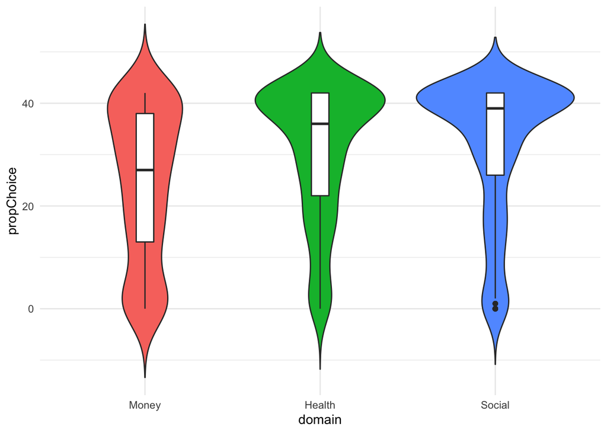

Effect

DFn

DFd

F

p

p<.05

ges

Age

1

231

15.427

0.000113

0.041

domain

2

462

38.140

0.000000

0.057

Age:domain

2

462

3.341

0.036000

0.005

### Sphericity check

Effect

W

p

p<.05

domain

0.963

0.014

Age:domain

0.963

0.014

### Sphericity correction

Effect

GGe

DF[GG]

p[GG]

p[GG]<.05

HFe

DF[HF]

p[HF]

p[HF]<.05

domain

0.965

1.93, 445.7

0.000

0.973

1.95, 449.38

0.000

Age:domain

0.965

1.93, 445.7

0.038

0.973

1.95, 449.38

0.038

### Follow-up Test

| .y. | group1 | group2 | n1 | n2 | statistic | df | p | p.adj | p.adj.signif |
| --- | --- | --- | --- | --- | --- | --- | --- | --- | --- |
| propChoice | Money | Health | 233 | 233 | -6.736796 | 232 | 0.000 | 0.000 | **** |
| propChoice | Money | Social | 233 | 233 | -7.503224 | 232 | 0.000 | 0.000 | **** |
| propChoice | Health | Social | 233 | 233 | -1.261531 | 232 | 0.208 | 0.624 | ns |

# Age effects

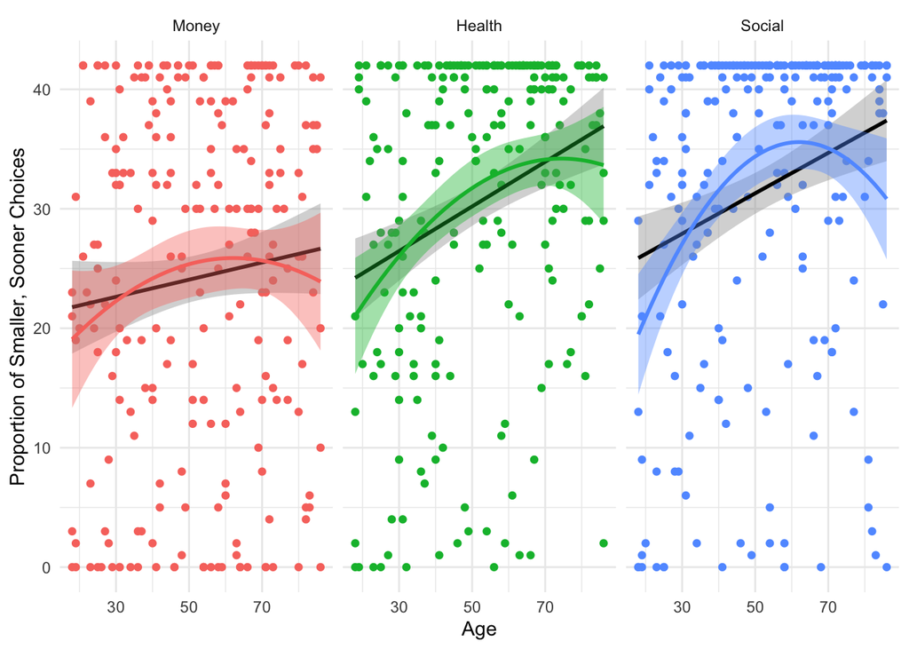

### Money

Model - Age

|  | Estimate | Std. Error | t value | Pr(>\|t\|) |
| --- | --- | --- | --- | --- |
| (Intercept) | -0.3274789 | 0.0681124 | -4.807919 | 0.0000027 |
| Age | 0.0985387 | 0.0681612 | 1.445671 | 0.1496248 |

Model - Age + Age^2

|  | Estimate | Std. Error | t value | Pr(>\|t\|) |
| --- | --- | --- | --- | --- |
| (Intercept) | -0.2352059 | 0.1005793 | -2.338511 | 0.0202186 |
| Age | 0.0920368 | 0.0682798 | 1.347936 | 0.1790050 |
| Age2 | -0.0924052 | 0.0741869 | -1.245574 | 0.2141881 |

No efffect of age on money discounting.

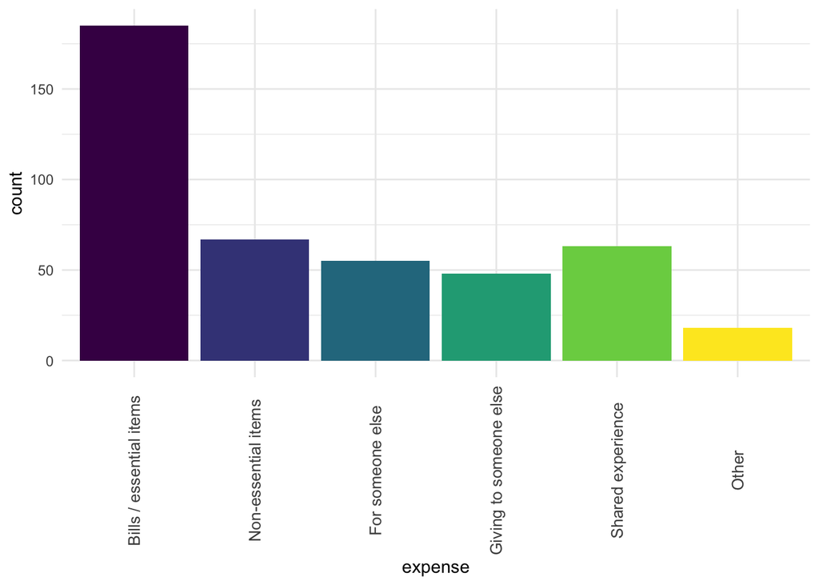

Q2169_1 = How important is getting more money, social contact, or health improvement to you right now? - Money

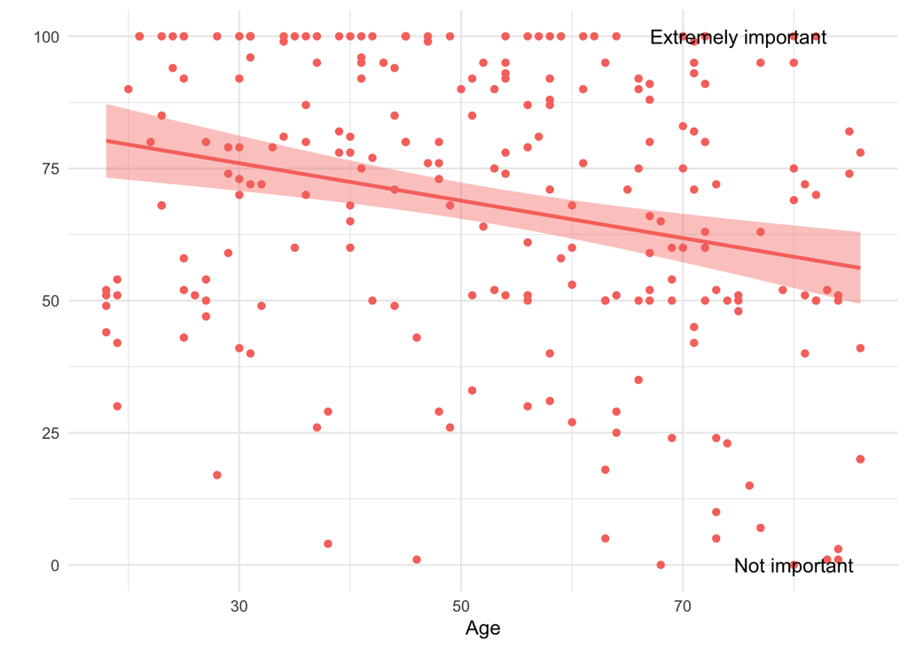

### Health

Model - Age

|  | Estimate | Std. Error | t value | Pr(>\|t\|) |
| --- | --- | --- | --- | --- |
| (Intercept) | 0.1264202 | 0.0577927 | 2.187476 | 0.0297109 |
| Age | 0.2558308 | 0.0578341 | 4.423527 | 0.0000150 |

Model - Age + Age^2

|  | Estimate | Std. Error | t value | Pr(>\|t\|) |
| --- | --- | --- | --- | --- |
| (Intercept) | 0.2358316 | 0.0850659 | 2.772340 | 0.0060215 |
| Age | 0.2481214 | 0.0577483 | 4.296603 | 0.0000256 |
| Age2 | -0.1095682 | 0.0627442 | -1.746267 | 0.0820996 |

Model comparison

| Res.Df | RSS | Df | Sum of Sq | F | Pr(>F) |
| --- | --- | --- | --- | --- | --- |
| 231 | 179.7689 | NA | NA | NA | NA |
| 230 | 177.4166 | 1 | 2.352274 | 3.049449 | 0.0820996 |

Significant linear effect of age on health discounting, with older adults discounting more than younger adults.

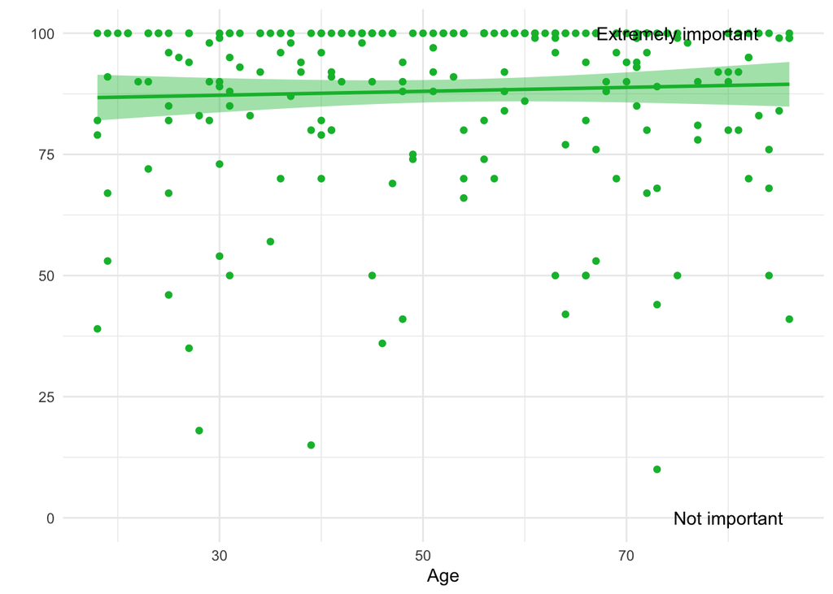

### Social

Model - Age

|  | Estimate | Std. Error | t value | Pr(>\|t\|) |
| --- | --- | --- | --- | --- |
| (Intercept) | 0.2010587 | 0.0610214 | 3.294887 | 0.0011394 |
| Age | 0.2317548 | 0.0610651 | 3.795207 | 0.0001885 |

Model - Age + Age^2

|  | Estimate | Std. Error | t value | Pr(>\|t\|) |
| --- | --- | --- | --- | --- |
| (Intercept) | 0.4207933 | 0.0882457 | 4.768426 | 0.0000033 |
| Age | 0.2162716 | 0.0599069 | 3.610126 | 0.0003756 |
| Age2 | -0.2200494 | 0.0650896 | -3.380713 | 0.0008493 |

Model comparison

| Res.Df | RSS | Df | Sum of Sq | F | Pr(>F) |
| --- | --- | --- | --- | --- | --- |
| 231 | 200.4162 | NA | NA | NA | NA |
| 230 | 190.9285 | 1 | 9.48767 | 11.42922 | 0.0008493 |

Significant linear and quadratic effects of age on social discounting, with older adults discounting more than younger adults and middle aged adults discounting more than younger or older adults

# Who are the social partners?

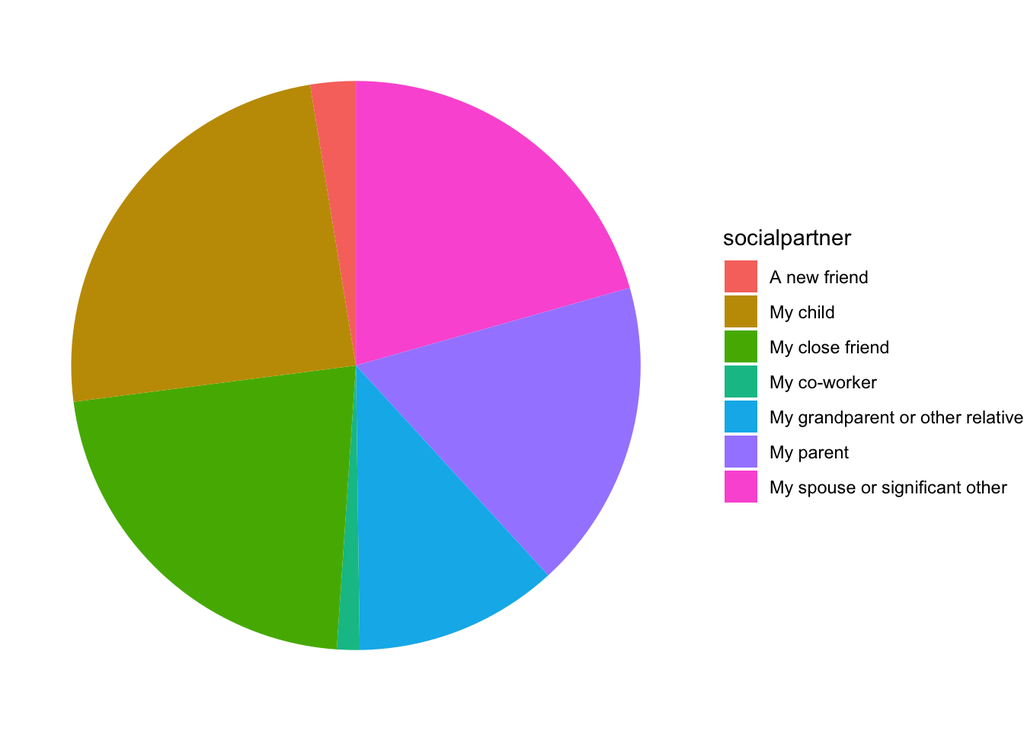

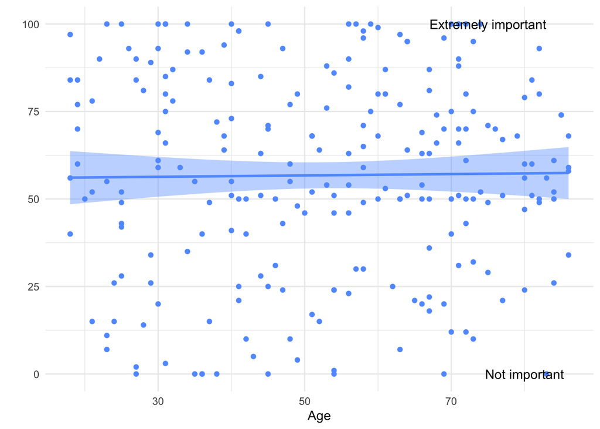